# Spatial-temporal modeling of environmental processes

# Modeling fire regime dynamics at mainland Spain

> Fire regime is defined as the average behavior of a set of key features, the remains stable over space and time (Rodrigues, Jiménez-Ruano, and Riva 2019)

### What are we going to do?

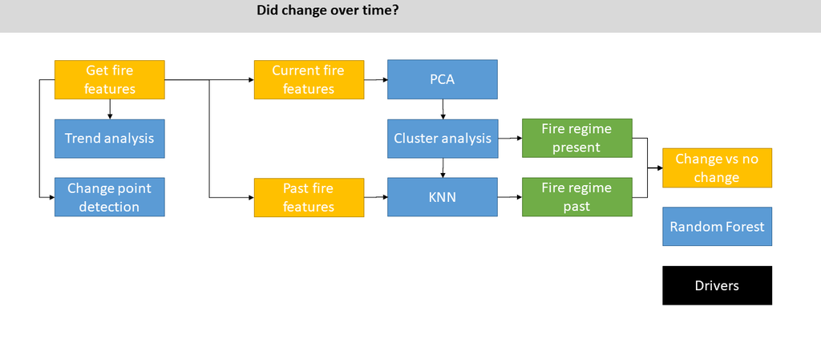

### Our data

```
## 'data.frame':    263195 obs. of  28 variables:
##  $ CODCUAD   : Factor w/ 4945 levels "0101H08","0101H09",..: 1 1 1 1 1 1 1 1 1 1 ...
##  $ IDPIF     : int  2003150499 1981150684 2000151564 2004151450 1984154481 1982151238 2013150568 2004152749 1984154480 2003151887 ...
##  $ X         : num  505693 NA 505693 502147 NA ...
##  $ Y         : int  4791760 NA 4791760 4791614 NA NA 4791081 4791614 NA 4791760 ...
##  $ HUSO.x    : int  29 NA 29 29 NA NA 29 29 NA 29 ...
##  $ DETECCION : Factor w/ 13219 levels "01/01/01","01/01/03",..: 2765 1621 3761 5426 10640 595 312 9880 10640 11612 ...
##  $ INCENDIOE : Factor w/ 13266 levels "","01/01/01",..: 2762 2056 3761 6310 10674 590 309 9905 11099 11645 ...
##  $ TOTALAR   : num  1.4 45 0 24.9 3.5 ...
##  $ TOTALNAR  : num  0 105 2 46.3 0 ...
##  $ SUPERNF   : num  NA NA NA NA NA NA NA NA NA NA ...
##  $ CAUSA     : int  4 4 2 4 4 5 4 4 4 4 ...
##  $ BAREA     : num  1.4 150 2 71.2 3.5 ...
##  $ MONTH     : int  5 9 8 6 6 5 9 9 6 9 ...
##  $ DAY       : int  7 4 9 13 25 2 1 23 25 27 ...
##  $ YEAR      : int  2003 1981 2000 2004 1984 1982 2013 2004 1984 2003 ...
##  $ Join_Count: int  1 1 1 1 1 1 1 1 1 1 ...
##  $ TARGET_FID: int  85 85 85 85 85 85 85 85 85 85 ...
##  $ HOJA      : int  101 101 101 101 101 101 101 101 101 101 ...
##  $ CUAD      : Factor w/ 264 levels "A01","A02","A03",..: 120 120 120 120 120 120 120 120 120 120 ...
##  $ HUSO.y    : int  29 29 29 29 29 29 29 29 29 29 ...
##  $ ZONA      : Factor w/ 2 levels "S","T": 2 2 2 2 2 2 2 2 2 2 ...
##  $ ORIG_FID  : int  85 85 85 85 85 85 85 85 85 85 ...
##  $ fid_      : int  115 115 115 115 115 115 115 115 115 115 ...
##  $ Lon       : num  -10 -10 -10 -10 -10 -10 -10 -10 -10 -10 ...
##  $ Lat       : num  42.5 42.5 42.5 42.5 42.5 42.5 42.5 42.5 42.5 42.5 ...
##  $ coords.x1 : num  -8.94 -8.94 -8.94 -8.94 -8.94 ...
##  $ coords.x2 : num  43.3 43.3 43.3 43.3 43.3 ...
##  $ DATE      : Factor w/ 13253 levels "1900-01-21","1900-02-04",..: 9210 2317 8324 9555 3203 2532 12496 9657 3203 9353 ...
```

```
## Classes 'sf', 'tbl_df', 'tbl' and 'data.frame':  5176 obs. of  4 variables:
##  $ Cod_Cuad  : chr  "0201C04" "0201C05" "0201C06" "0201C07" ...
##  $ COD_CCAA_1: chr  "12" "12" "12" "12" ...
##  $ NOMBRE    : chr  "Galicia" "Galicia" "Galicia" "Galicia" ...
##  $ geometry  :sfc_MULTIPOLYGON of length 5176; first list element: List of 1
##   ..$ :List of 1
##   .. ..$ : num [1:7, 1:2] 96586 96556 92357 92375 93587 ...
##   ..- attr(*, "class")= chr  "XY" "MULTIPOLYGON" "sfg"
##  - attr(*, "sf_column")= chr "geometry"
##  - attr(*, "agr")= Factor w/ 3 levels "constant","aggregate",..: NA NA NA
##   ..- attr(*, "names")= chr  "Cod_Cuad" "COD_CCAA_1" "NOMBRE"
```

```
## 'data.frame':    5037 obs. of  11 variables:
##  $ Cod_Cuad: Factor w/ 5008 levels "0101H08","0101H09",..: 1 2 3 4 5 6 7 8 9 10 ...
##  $ wai90   : num  28389 85901 43033 102216 3640 ...
##  $ wui90   : num  1471 1918 0 2404 0 ...
##  $ dempot  : num  -8.1 -7.71 1.31 3.84 -4.46 ...
##  $ waiCh   : num  -2.96e-06 8.71e-07 9.73e-07 -5.16e-01 -1.10e-05 ...
##  $ wuiCh   : num  0 0 0 0 0 0 0 0 0 0 ...
##  $ temp    : num  0.0512 0.0512 0.0516 0.0462 0.0432 ...
##  $ prec    : num  0.584 0.584 1.217 2.682 0.823 ...
##  $ elev    : num  97 82 93 140 117 ...
##  $ slope   : num  2.43 1.07 3.45 3.2 2.78 ...
##  $ roads   : num  16139 45882 29518 60487 3745 ...
```

## Time series analysis

As a preliminary step towards fire regime modeling we must ascertain whether fire regime features (number of fires, burneda area, large fires, cause or seasonality) vary over time.

Time series analysis comprises a wide array of tools to investigate temporal changes. In this workshop we will keep it simple, limiting the analysis the identification of temporal trends on a yearly basis. First, let’s plot the temporal evolution of the most representative fire regime features, i.e., number of fires and burned area:

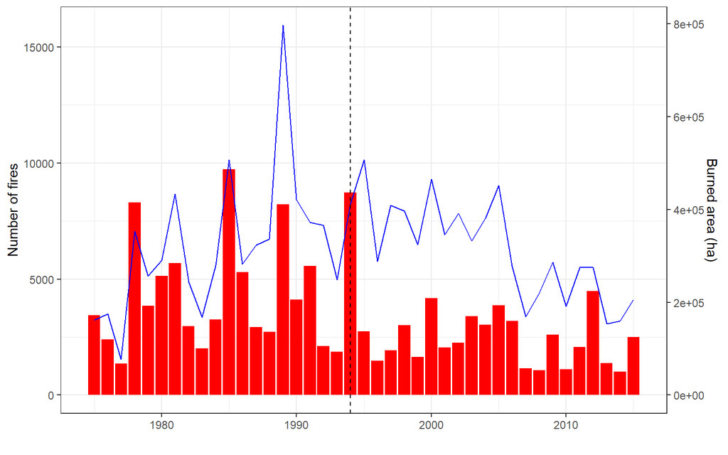

```r
fires.year <- fires %>%
  filter(YEAR>1974) %>%
  group_by(YEAR) %>%
  summarise(N=n(),BA=sum(BAREA))

ggplot(data=fires.year) +
    geom_bar(aes(x=YEAR,y=BA/50),
           stat = 'identity',fill='red') +
  geom_line(aes(x=YEAR,y=N),color = 'blue') +
  scale_y_continuous(sec.axis = sec_axis(~.*50, name = "Burned area (ha)")) +
  # scale_colour_manual(values = c("red", "blue")) +
  geom_vline(xintercept = 1994,lty=2)+
  labs(y = "Number of fires",
       x = "",
       colour = "") +
  theme_bw() +
  theme(legend.position = 'bottom')
```

It seems that burned area decreased over time. Let’s check if the evolution that we can perceive by visual inspection it’s actually true (that means statistically significant). We are going apply the Mann-Kendall test (Kendall 1975) to investigate the existence of trends and, in case there’s any actual trend, we will check when is the major breakpoint in the time series using the Pettit test (Pettitt 1979):

```r
mk.test(fires.year$N)
```

```
##
##  Mann-Kendall trend test
##
## data:  fires.year$N
## z = -0.64022, n = 41, p-value = 0.522
## alternative hypothesis: true S is not equal to 0
## sample estimates:
##             S          varS           tau
##  -58.00000000 7926.66666667   -0.07073171
```

```r
mk.test(fires.year$BA)
```

```
##
##  Mann-Kendall trend test
##
## data:  fires.year$BA
## z = -2.617, n = 41, p-value = 0.00887
## alternative hypothesis: true S is not equal to 0
## sample estimates:
##            S         varS          tau
## -234.0000000 7926.6666667   -0.2853659
```

```r
pettitt.test(fires.year$BA)
```

```
##
##  Pettitt's test for single change-point detection
##
## data:  fires.year$BA
## U* = 222, p-value = 0.03034
## alternative hypothesis: two.sided
## sample estimates:
## probable change point at time K                            <NA>
##                              17                              20
```

According to the Mann-Kendall test there is a significant trend in burned area (p<0.05). The Pettit test identified two possible breakpoints at position 17 (1991) and 20 (1994). That implies we cannot model fire regime using the entire period but must split the time series at least into two subsamples. We are going to take the year 1994 as main change point (Jiménez-Ruano, Rodrigues Mimbrero, and de la Riva Fernández 2017) and analyze the periods 1974-1994 and 1995-2015, separately.

First things first, we need to build our fire features, We will follow the suggest varibles in Rodrigues, Jiménez-Ruano, and Riva (2019) and create the following features:

```r
features_1 <- fires %>%
  filter(YEAR>1994,BAREA>1) %>%
  group_by(CODCUAD, YEAR,.drop = F) %>%
  summarise(N = n(),BA = sum(BAREA)) %>%
  group_by(CODCUAD,.drop = F) %>%
  summarise(N = mean(N),BA = mean(BA))

features_2 <- fires %>%
  filter(YEAR>1994,BAREA>1) %>%
  filter(CAUSA == 1) %>%
  group_by(CODCUAD, YEAR, MONTH, .drop = F) %>%
  summarise(NL= n(),BAL=sum(BAREA))%>%
  group_by(CODCUAD,.drop = F) %>%
  summarise(BAL = mean(BAL))

features_3 <- fires %>%
  filter(YEAR>1994,BAREA>1) %>%
  filter(BAREA>100) %>%
  group_by(CODCUAD,YEAR,MONTH,.drop = F) %>%
  summarise(BA100 = mean(BAREA))%>%
  group_by(CODCUAD,.drop = F) %>%
  summarise(BA100 = mean(BA100))

features_4 <- fires %>%
  filter(YEAR>1994,BAREA>1) %>%
  filter(MONTH < 5 | MONTH>9) %>%
  group_by(CODCUAD, YEAR,.drop = F) %>%
  summarise(NW=n())%>%
  group_by(CODCUAD,.drop = F) %>%
  summarise(NW = mean(NW))

features.present <- left_join(features_1,features_2,by='CODCUAD') %>%
  left_join(features_3,by='CODCUAD') %>%
  left_join(features_4,by='CODCUAD')

features.present[is.na(features.present)] <- 0
```

## Identify fire regime typologies

The first step involves the identification and characterization of fire regimes. To do so, we will leverage `clustering` techniques.

> Cluster analysis allows grouping a set of objects in such a way that objects in the same group (called a cluster) are more similar to each other than to those in other groups (clusters). [Wikipedia.org](https://en.wikipedia.org/wiki/Cluster_analysis)

As a preliminary step, we will apply Principal Component Analysis (PCA). Although not mandatory, PCA enhances the separabilty of objects will reducing the amount of information (dimensions) to perform the cluster analysis. Furthermore, PCA is also a useful exploratory technique that will grant us a better understanding of our dataset.

Note that we enabled the `scale` and `center` options to rescales the original data, centering them to mean 0, and standartizing them as the ratio of the standard deviation.

```r
pca <- prcomp(features.present[,2:6],scale=T,center = T)
summary(pca)
```

```
## Importance of components:
##                           PC1    PC2    PC3    PC4     PC5
## Standard deviation     1.4359 1.3148 0.9495 0.4894 0.26130
## Proportion of Variance 0.4124 0.3458 0.1803 0.0479 0.01366
## Cumulative Proportion  0.4124 0.7581 0.9385 0.9863 1.00000
```

```r
pca$rotation
```

```
##              PC1        PC2         PC3          PC4         PC5
## N     -0.5608912  0.4277823 -0.02863438 -0.001326868 -0.70822432
## BA    -0.4342420 -0.4895814  0.30133399  0.692630601  0.03470750
## BAL   -0.1742815 -0.2887865 -0.93668577  0.094055518  0.00128750
## BA100 -0.4003819 -0.5489784  0.17213345 -0.712938937 -0.02012852
## NW    -0.5533130  0.4387909 -0.03698306 -0.055970719  0.70484529
```

```r
cluster.data <- pca$x[,1:3]
```

PCA’s outputs suggest keeping the first 3 components, gathering up to 93.(%) of the variance. These components may be interpreted as follows:

- PC1 (41.2%): High fire activity, mostly linked to non-natural fires.
- PC2 (34.6%): Large fire frequency during winter.
- PC3 (18.0%): Small natural fires.

Once, key components are identify we submit them to cluster analysis. There is a wide range of clustering approaches. In this example we used the `nbClust` package. It appies hierarchical clustering, offering several dissimilarty measures and grouping strategies. It also provides a way to optimize the number of clusters to be fitted.

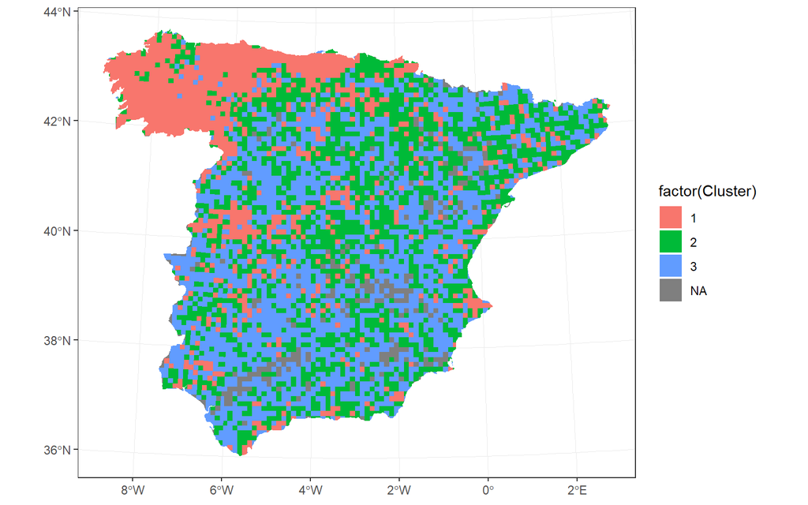

```r
#Cluster parameters
d <- "canberra"
m <- "ward.D2"
index <- "silhouette"

#Optimizing cluster model
cluster.present <- NbClust(cluster.data,index= index, distance = d,
                    min.nc = 3,
                    max.nc = 3, method = m)

features.present$Cluster <- cluster.present$Best.partition
grid.present <- left_join(grid,features.present,
                          by=c('Cod_Cuad' ='CODCUAD'))
map.present <- ggplot(grid.present,aes(fill=factor(Cluster))) +
  geom_sf(color=NA) +
  theme_bw()

map.present
```

To keep it simple, we forced the algorithm to fit 3 clusters. As you may know, clustering is a type of unsupervised learning technique. That implyis we do not know the patterns data follows. Thus it is of critical importance to carefully examine the results to understand them and see if they are meaningul enough.

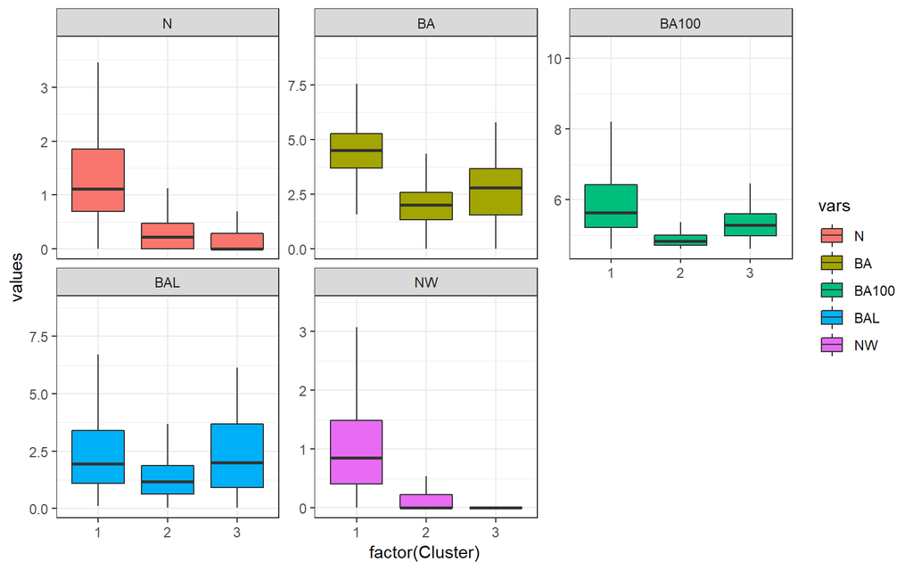

```r
features.cluster <- features.present %>%
  na.omit() %>%
  group_by(Cluster) %>%
  # summarise_at(vars(N:NW),mean) %>%
  mutate_at(vars(N:NW),log) %>%
  # summarise_at(vars(N:NW),mean) %>%
  gather('vars','values',2:6)

features.cluster$vars <- fct_relevel(as.factor(features.cluster$vars),'N','BA','BA100','BAL','NW')

ggplot(features.cluster,aes(x=factor(Cluster),y=values,fill=vars)) +
  geom_boxplot(outlier.shape = NA) +
  # geom_bar(stat = 'identity') +
  facet_wrap(~vars, scales = 'free_y') +
  theme_bw()
```

This is a very shallow description but already meaningul. To facilitate the next steps, we can relabel the groups in increasing order of hazardouseness (3 most threatening situation, 1 low activity). Thus, regime 1 will be tagged as 3, regime 3 as 2 and regime 2 as 1.

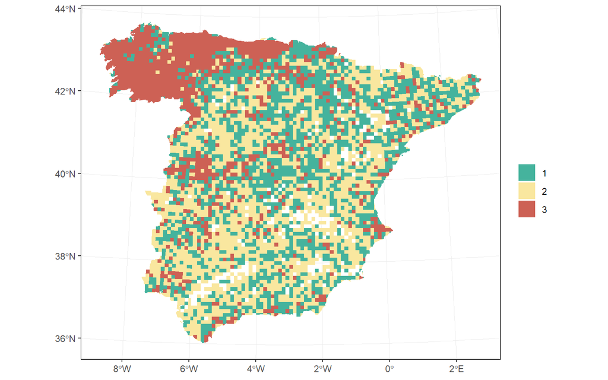

```r
features.present$Cluster <- recode(as.character(features.present$Cluster),
                                   '1' = '3', '2' ='1', '3' = '2' )

grid.present <- left_join(grid,features.present,
                          by=c('Cod_Cuad' ='CODCUAD'))
map.present <- ggplot(na.omit(grid.present),aes(fill=factor(Cluster))) +
  geom_sf(color=NA) +
  scale_fill_manual(name = '',
                    values = c('1' = '#45b39d','2'='#f9e79f','3'='#cd6155')) +
  theme_bw()

map.present
```

## Transferring fire regimes into the past

To solve this problem we can take advantage of `classification` modeling. In this ocasion, we are facing a supervised learning technique because what we want to do is use the information about current clusters, including cluster labels, to classify past fire events according to the observed typologies in the present. So, in this case we already know to what regime belongs each cell in the grid, and also the values of each fire feature.

We just need to replicate our fire features under past conditions and then apply a classification technique to transfer our typologies.

```r
features_1 <- fires %>%
  filter(YEAR < 1994, BAREA > 1) %>%
  group_by(CODCUAD, YEAR, .drop = F) %>%
  summarise(N = n(), BA = sum(BAREA)) %>%
  group_by(CODCUAD, .drop = F) %>%
  summarise(N = mean(N), BA = mean(BA))

features_2 <- fires %>%
  filter(YEAR < 1994, BAREA > 1) %>%
  filter(CAUSA == 1) %>%
  group_by(CODCUAD, YEAR, MONTH, .drop = F) %>%
  summarise(NL = n(), BAL = sum(BAREA)) %>%
  group_by(CODCUAD, .drop = F) %>%
  summarise(BAL = mean(BAL))

features_3 <- fires %>%
  filter(YEAR < 1994, BAREA > 1) %>%
  filter(BAREA > 100) %>%
  group_by(CODCUAD, YEAR, MONTH, .drop = F) %>%
  summarise(BA100 = mean(BAREA)) %>%
  group_by(CODCUAD, .drop = F) %>%
  summarise(BA100 = mean(BA100))

features_4 <- fires %>%
  filter(YEAR < 1994, BAREA > 1) %>%
  filter(MONTH < 5 | MONTH > 9) %>%
  group_by(CODCUAD, YEAR, .drop = F) %>%
  summarise(NW = n()) %>%
  group_by(CODCUAD, .drop = F) %>%
  summarise(NW = mean(NW))

features.past <-
  left_join(features_1, features_2, by = 'CODCUAD') %>%
  left_join(features_3, by = 'CODCUAD') %>%
  left_join(features_4, by = 'CODCUAD')

features.past[is.na(features.past)] <- 0
```

This sets it up in terms of fire features. Now, how do we conduct the classification procedure. Same as in the clustering problem, we have many alternatives when it comes to classification. For instance, we may apply `Random Forest`, an algorithm that we’ll explore later on. In this case, one technique that really suits the purpose is the `K-Nearest Neighbor` (KNN) algorithm beacuse it uses dissimilarity measures (same as clustering does) to classify each observation into its more convenient group.

```r
library(knnGarden)
```

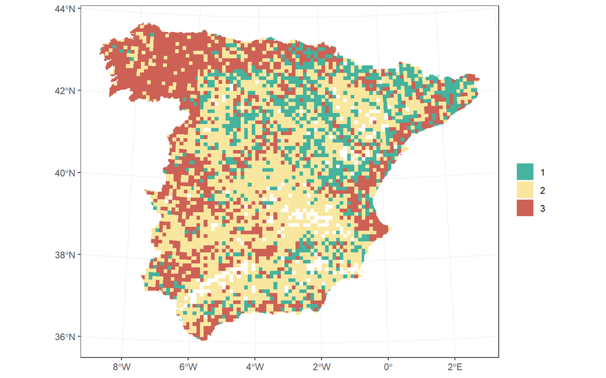

```r
library(class)

# knn.past <- knnVCN(TrnX = features.present[,2:6],
#                 OrigTrnG = features.present$Cluster,
#                 TstX = features.past[,2:6],
#                 ShowObs=FALSE,K=1,method="canberra",p = 2)

knn.past <- knn(train = features.present[,2:6],
                test = features.past[,2:6],
                cl = features.present$Cluster, k=5)

features.past$Cluster <- knn.past
grid.past <- left_join(grid,features.past,
                          by=c('Cod_Cuad' ='CODCUAD'))
map.past <- ggplot(na.omit(grid.past),aes(fill=factor(Cluster))) +
  geom_sf(color=NA) +
  scale_fill_manual(name = '',
                    values = c('1' = '#45b39d','2'='#f9e79f','3'='#cd6155')) +
  theme_bw()

map.past
```

It must be noted that we applied the *regular* version of KNN, which is based on euclidan distance. However, since we used `canberra` distance as our dissimilarity measure when fitting the cluster, the ideal would be using the same distance approach. In the previous chunck of code you can find the `knnVCN` alternative that has been discarded since it takes a very long time to run.

That being said, we still have to do something. Classification is a supervised learning technique, so we must assess its performance in some way to determine to which extent its outputs may be trusted. Fortunately for us, the `knn.cv` function allows to conduct a Leave-One-Out Cross-Validation (LOOCV) procedure without requiring us to code it on our own.

```r
cv <-knn.cv(train = features.present[,2:6],k = 5,
       cl = features.present$Cluster)

caret::confusionMatrix(as.factor(cv),as.factor(features.present$Cluster))
```

```
## Confusion Matrix and Statistics
##
##           Reference
## Prediction    1    2    3
##          1 1649   88   73
##          2   95 1845  168
##          3   22  156  849
##
## Overall Statistics
##
##                Accuracy : 0.8783
##                  95% CI : (0.8688, 0.8873)
##     No Information Rate : 0.4224
##     P-Value [Acc > NIR] : < 2.2e-16
##
##                   Kappa : 0.8108
##
##  Mcnemar's Test P-Value : 3.475e-06
##
## Statistics by Class:
##
##                      Class: 1 Class: 2 Class: 3
## Sensitivity            0.9337   0.8832   0.7789
## Specificity            0.9494   0.9079   0.9538
## Pos Pred Value         0.9110   0.8752   0.8267
## Neg Pred Value         0.9627   0.9140   0.9385
## Prevalence             0.3571   0.4224   0.2204
## Detection Rate         0.3335   0.3731   0.1717
## Detection Prevalence   0.3660   0.4263   0.2077
## Balanced Accuracy      0.9416   0.8956   0.8664
```

We are almost done. Let’s take a look into the transition matrix, i.e., a table summarazing the combinations of fire regimes from the past towards present.

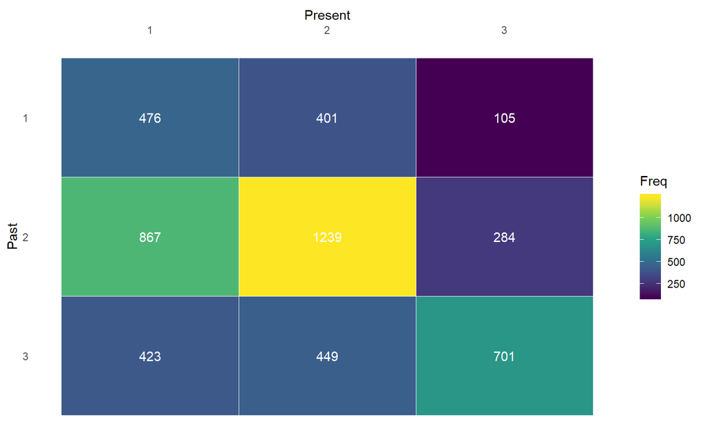

```r
tm <- as.data.frame(table(past = features.past$Cluster,
      present = features.present$Cluster))

ggplot(tm, aes(x=as.numeric(present),y=as.numeric(past),fill=Freq)) +
  geom_tile(color='white') +
  scale_fill_viridis_c(option = 'D') +
  scale_y_reverse(name='Past') +
  scale_x_continuous(name = 'Present', position = "top") +
  geom_text(aes(label=Freq),color='white') +
  theme_minimal() +
  theme(panel.grid = element_blank())
```

Finally, let’s go and compare the spatial distribution of past and current regimes:

```r
library(ggpubr)
```

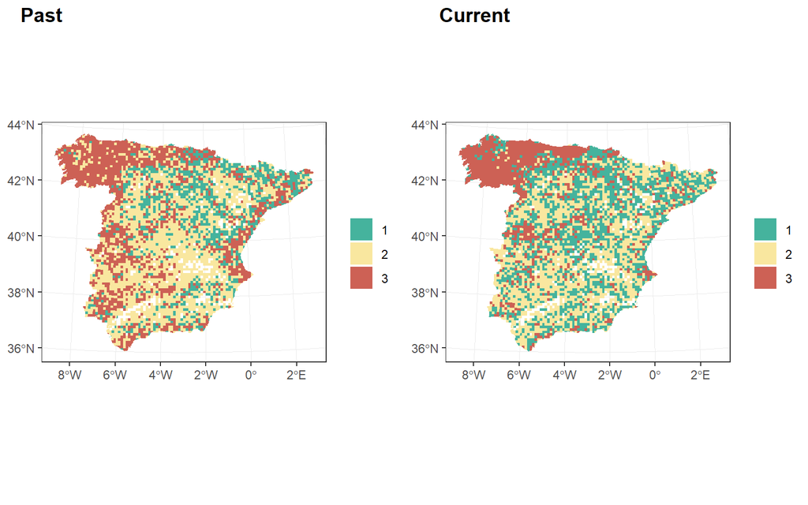

```r
ggarrange(map.past, map.present,
          labels = c("Past", "Current"),
          ncol = 2)
```

Both the transition matrix and the map comparison highlight the main transition as a downgrade in fire activity, with mostly declining trajectories (from 3 to 1, from 2 to 1), though progressive transitions were also found.

## Which factors drove the change in fire regime?

This will be our last analysis. It aims at identifying under which circumstances the change of fire regime is triggered or what conditions favor the persistence of a given fire regime type.

We will apply regression models to fullfil the taks. We will compare two techniques allowing for binary regression (change vs no change in fire regime) to determine the chances of change happening. First, we will fit a `logit regression` model. Then we will train a `Random Forest` model. Both models will be evaluated in terms of performance. The one that work best will be subsequently explored in terms of variable performance and explanatory sense.

First, we will read a table with our explanatory variables, and merge the information about fire regime transition:

```r
clusters <- cbind(features.past[,c(1,7)],features.present[,7])
names(clusters)[2:3] <- c('Past','Present')
clusters$Change <- paste(clusters$Past,clusters$Present,sep = '-')

data.regresion <- left_join(variables,clusters,by=c('Cod_Cuad' = 'CODCUAD'))
```

Our variables are as follows:

- wai90: wildland-agricultural interface. Use of fire as a tool to cleanse plots or remove residues.
- wui90: wildland-urban interface. Increases pressure on wildlands and forests.
- dempot: increase in population density.
- temp: trend in temperature.
- prec: trend in annual rainfall.
- elev: elevation in meters above the sea level.
- slope: inclination of the relief.
- roads: length of the road network. Increased accessibility.

Now, let’s build our dependent variable, i.e., change (1) and no change (0) of fire regime. We will focus on an increasing transition, from intermediate fire incidence (regime 2) to hazardous conditions (regime 3). So, let’s extract the subset of observation that meet the criteria and recode them into a binary variable (1-0):

```r
data.model <- filter(data.regresion,Change=='2-3' | Change=='2-2')
data.model <- mutate(data.model,Change = ifelse(Change=='2-3',1,0))
```

Logistic regression models require our data to be linearly independent, that means that explanatory variables must be uncorrelated among them. A correlogram will assist us un such task:

```r
library(corrplot)
M<-cor(data.model[,-c(1,12:14)])
sig <- cor.mtest(data.model[,-c(1,12:14)], conf.level = .95)
```

[output not shown]

Aparently all variables are good to go. Now let’s split our data into training and testing samples:

```r
set.seed(100)
training.rows <- sample(row(data.model),floor(nrow(data.model)*0.7))
data.train <- data.model[training.rows,]
data.test <- data.model[-training.rows,]
```

Let’s fit and inspect the logit model:

```r
model.logit  <- glm(Change~wuiCh+elev+slope+dempot+temp+prec+roads,
                    data=data.train,
                    family = binomial())

summary(model.logit)
```

```
##
## Call:
## glm(formula = Change ~ wuiCh + elev + slope + dempot + temp +
##     prec + roads, family = binomial(), data = data.train)
##
## Deviance Residuals:
##     Min       1Q   Median       3Q      Max
## -1.6281  -0.6212  -0.4481  -0.2914   3.0743
##
## Coefficients:
##               Estimate Std. Error z value Pr(>|z|)
## (Intercept) -3.056e+00  5.651e-01  -5.409 6.35e-08 ***
## wuiCh       -9.802e-03  5.416e-03  -1.810 0.070335 .
## elev        -1.289e-03  3.117e-04  -4.136 3.54e-05 ***
## slope        2.799e-01  4.736e-02   5.909 3.43e-09 ***
## dempot      -9.019e-02  1.672e-02  -5.394 6.89e-08 ***
## temp         1.152e+01  9.543e+00   1.207 0.227333
## prec        -1.912e-01  5.680e-02  -3.366 0.000761 ***
## roads        4.313e-05  5.163e-06   8.353  < 2e-16 ***
## ---
## Signif. codes:  0 '***' 0.001 '**' 0.01 '*' 0.05 '.' 0.1 ' ' 1
##
## (Dispersion parameter for binomial family taken to be 1)
##
##     Null deviance: 1002.67  on 997  degrees of freedom
## Residual deviance:  808.18  on 990  degrees of freedom
## AIC: 824.18
##
## Number of Fisher Scoring iterations: 5
```

Now we check its performance:

```r
library(dismo)
```

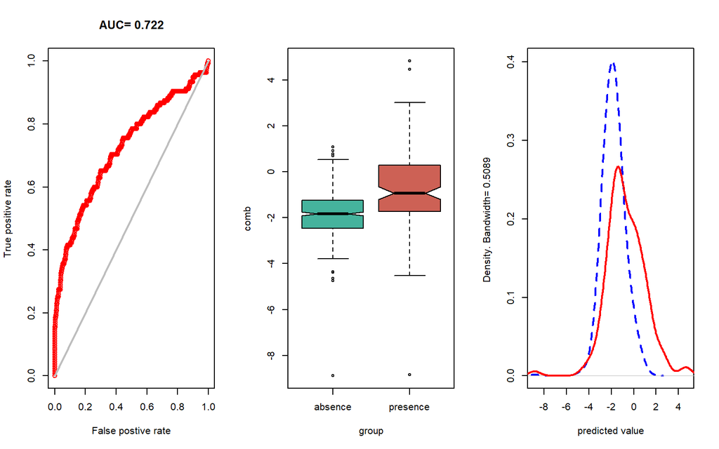

```r
eval.logit<-evaluate(p=data.test[data.test$Change==1,],
                     a=data.test[data.test$Change==0,],
                     model=model.logit)

par(mfrow=c(1,3))
plot(eval.logit,'ROC')
boxplot(eval.logit, col = c('#45b39d', '#cd6155'))
density(eval.logit)
```

And we do the same but using Random Forest:

```r
library(randomForest)
model.rf  <- randomForest(Change~wai90+elev+slope+dempot+prec+roads,
                    data=data.train)
model.rf
```

```
##
## Call:
##  randomForest(formula = Change ~ wai90 + elev + slope + dempot +      prec + roads, data = data.train)
##                Type of random forest: regression
##                      Number of trees: 500
## No. of variables tried at each split: 2
##
##           Mean of squared residuals: 0.07669017
##                     % Var explained: 52.32
```

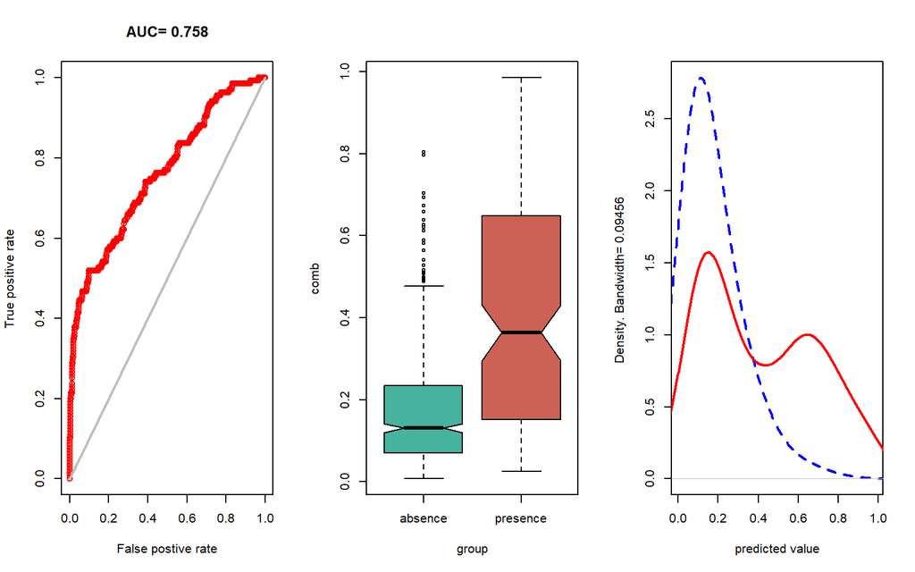

```r
# Model evaluation with test sample
eval.rf<-evaluate(p=data.test[data.test$Change==1,],
                     a=data.test[data.test$Change==0,],
                     model=model.rf)

par(mfrow=c(1,3))
plot(eval.rf,'ROC')
boxplot(eval.rf, col = c('#45b39d', '#cd6155'))
density(eval.rf)
```

Since Random Forest seems to outperform logit regression we will take a look at the performane and explanatory sense of the predictors:

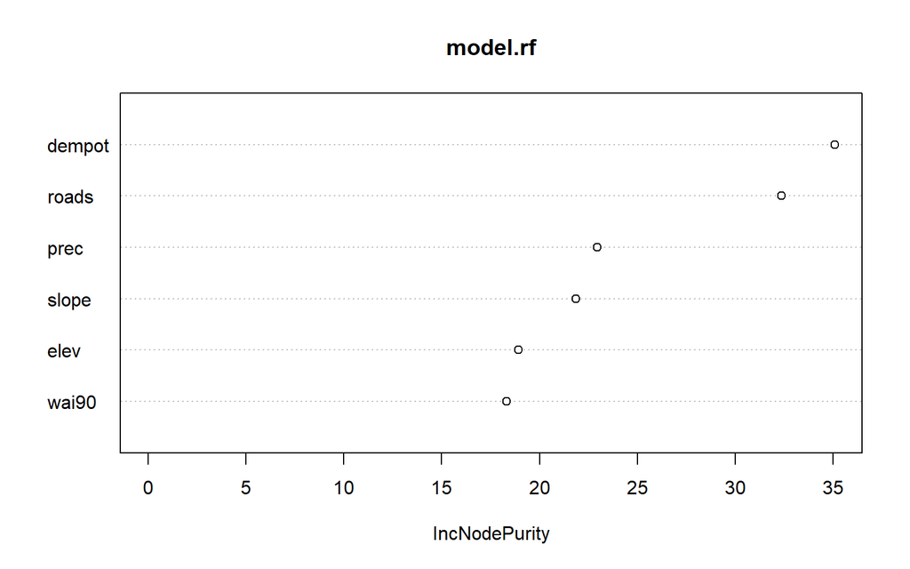

```r
varImpPlot(model.rf)
```

```
##  plotmo grid:    wai90     elev   slope   dempot      prec    roads
##               75565.78 677.9784 1.61753 1.818905 0.2266667 26773.74
```

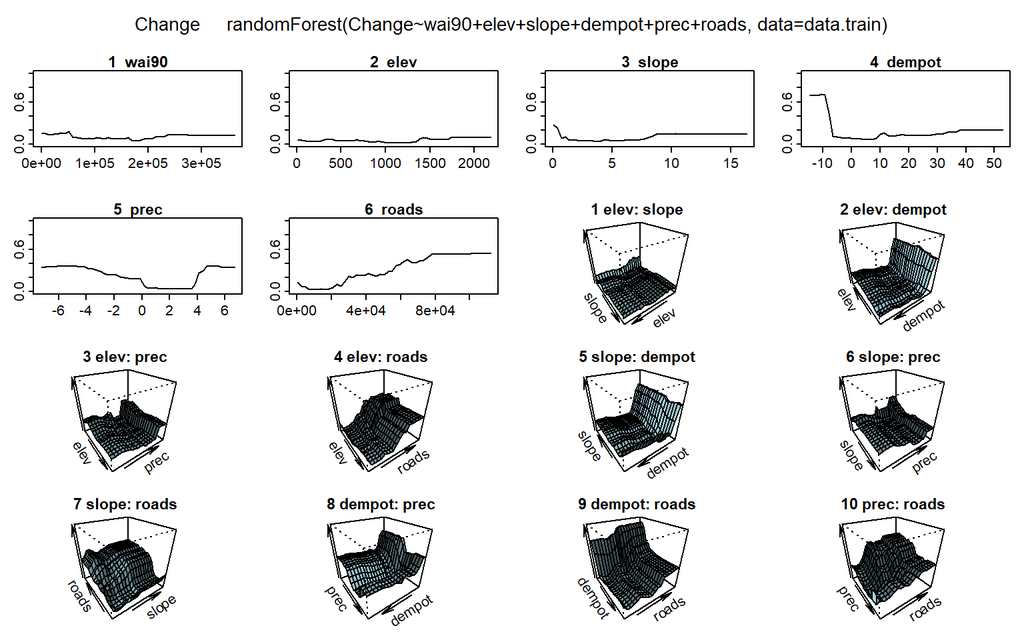

```r
library(plotmo)
plotmo(model.rf)
```

# References

Jiménez-Ruano, Adrián, Marcos Rodrigues Mimbrero, and Juan de la Riva Fernández. 2017. “Exploring spatial – temporal dynamics of fire regime features in mainland Spain.” *Natural Hazards and Earth System Science* 17: 1697–1711. doi:https://doi.org/10.5194/nhess-17-1697-2017.

Kendall, M G. 1975. *Rank correlation methods*. Edited by Charles Griffin. 4th ed. London.

Pettitt, A N. 1979. “A Non-Parametric Approach to the Change-Point Problem.” *Journal of the Royal Statistical Society. Series C (Applied Statistics)* 28 (2): 126–35.

Rodrigues, Marcos, Adrián Jiménez-Ruano, and Juan de la Riva. 2019. “Fire regime dynamics in mainland Spain. Part 1: Drivers of change.” *Science of the Total Environment*, 135841. doi:https://doi.org/10.1016/j.scitotenv.2019.135841.

Marcos Rodrigues

17/02/2020, 18/02/2020, 24/02/2020